# survival_project

# 5. Multivariable Cox model + stepwise selection

Now we put all variables significant at p<0.2 and fit a multivariable proportional hazards model

```r
cox_full <- coxph(
  surv_obj ~ Age +
    Race + Marital.Status + N.Stage + Grade + A.Stage +
    Tumor.Size + Estrogen.Status + Progesterone.Status +
    Regional.Node.Examined + Regional.Node.Positive,
  data = seer_train
)

summary(cox_full)
```

```
## Call:
## coxph(formula = surv_obj ~ Age + Race + Marital.Status + N.Stage +
##     Grade + A.Stage + Tumor.Size + Estrogen.Status + Progesterone.Status +
##     Regional.Node.Examined + Regional.Node.Positive, data = seer_train)
##
##   n= 3621, number of events= 556
##
##                                  coef exp(coef)  se(coef)      z Pr(>|z|)
## Age                          0.021457  1.021689  0.005107  4.201 2.65e-05 ***
## RaceOther                   -0.720392  0.486561  0.227254 -3.170 0.001524 **
## RaceWhite                   -0.305301  0.736901  0.136706 -2.233 0.025531 *
## Marital.StatusMarried       -0.237022  0.788974  0.125398 -1.890 0.058737 .
## Marital.StatusSeparated      0.436158  1.546753  0.299096  1.458 0.144771
## Marital.StatusSingle        -0.064319  0.937706  0.153668 -0.419 0.675538
## Marital.StatusWidowed       -0.048990  0.952191  0.188376 -0.260 0.794815
## N.StageN2                    0.495982  1.642110  0.115165  4.307 1.66e-05 ***
## N.StageN3                    0.636354  1.889578  0.189289  3.362 0.000774 ***
## Grade1                      -1.541026  0.214161  0.397596 -3.876 0.000106 ***
## Grade2                      -1.099726  0.332962  0.364060 -3.021 0.002522 **
## Grade3                      -0.704396  0.494407  0.363027 -1.940 0.052339 .
## A.StageRegional             -0.387895  0.678484  0.193630 -2.003 0.045147 *
## Tumor.Size                   0.007243  1.007269  0.001740  4.163 3.15e-05 ***
## Estrogen.StatusPositive     -0.655457  0.519205  0.143645 -4.563 5.04e-06 ***
## Progesterone.StatusPositive -0.415551  0.659977  0.113010 -3.677 0.000236 ***
## Regional.Node.Examined      -0.028790  0.971621  0.006757 -4.261 2.04e-05 ***
## Regional.Node.Positive       0.052565  1.053971  0.011937  4.403 1.07e-05 ***
## ---
## Signif. codes:  0 '***' 0.001 '**' 0.01 '*' 0.05 '.' 0.1 ' ' 1
##
##                             exp(coef) exp(-coef) lower .95 upper .95
## Age                            1.0217     0.9788   1.01151    1.0320
## RaceOther                      0.4866     2.0552   0.31167    0.7596
## RaceWhite                      0.7369     1.3570   0.56370    0.9633
## Marital.StatusMarried          0.7890     1.2675   0.61705    1.0088
## Marital.StatusSeparated        1.5468     0.6465   0.86066    2.7798
## Marital.StatusSingle           0.9377     1.0664   0.69385    1.2673
## Marital.StatusWidowed          0.9522     1.0502   0.65823    1.3774
## N.StageN2                      1.6421     0.6090   1.31031    2.0579
## N.StageN3                      1.8896     0.5292   1.30389    2.7383
## Grade1                         0.2142     4.6694   0.09824    0.4668
## Grade2                         0.3330     3.0033   0.16312    0.6796
## Grade3                         0.4944     2.0226   0.24270    1.0072
## A.StageRegional                0.6785     1.4739   0.46422    0.9916
## Tumor.Size                     1.0073     0.9928   1.00384    1.0107
## Estrogen.StatusPositive        0.5192     1.9260   0.39180    0.6880
## Progesterone.StatusPositive    0.6600     1.5152   0.52885    0.8236
## Regional.Node.Examined         0.9716     1.0292   0.95884    0.9846
## Regional.Node.Positive         1.0540     0.9488   1.02960    1.0789
##
## Concordance= 0.739  (se = 0.011 )
## Likelihood ratio test= 426.3  on 18 df,   p=<2e-16
## Wald test            = 495.7  on 18 df,   p=<2e-16
## Score (logrank) test = 563.4  on 18 df,   p=<2e-16
```

# Step 2 and 3: Identify covariates that might be removed, refit and check for possible

confounders

From multivariable proportional hazards model in step 1, covariate with largest p-value is in marital status followed by A Stage. So lets remove and refit the model by removing marital status

```r
cox_1 <- coxph(
  surv_obj ~ Age +
    Race + N.Stage + Grade + A.Stage +
    Tumor.Size + Estrogen.Status + Progesterone.Status +
    Regional.Node.Examined + Regional.Node.Positive,
  data = seer_train
)

summary(cox_1)
```

```
## Call:
## coxph(formula = surv_obj ~ Age + Race + N.Stage + Grade + A.Stage +
##     Tumor.Size + Estrogen.Status + Progesterone.Status + Regional.Node.Examined +
##     Regional.Node.Positive, data = seer_train)
##
##   n= 3621, number of events= 556
##
##                                  coef exp(coef)  se(coef)      z Pr(>|z|)
## Age                          0.022389  1.022641  0.004939  4.533 5.81e-06 ***
## RaceOther                   -0.809701  0.444991  0.224189 -3.612 0.000304 ***
## RaceWhite                   -0.374240  0.687812  0.133848 -2.796 0.005174 **
## N.StageN2                    0.482610  1.620297  0.114947  4.199 2.69e-05 ***
## N.StageN3                    0.603057  1.827697  0.189062  3.190 0.001424 **
## Grade1                      -1.568264  0.208407  0.396717 -3.953 7.71e-05 ***
## Grade2                      -1.124557  0.324796  0.362935 -3.099 0.001945 **
## Grade3                      -0.727955  0.482895  0.361739 -2.012 0.044180 *
## A.StageRegional             -0.372232  0.689195  0.193253 -1.926 0.054088 .
## Tumor.Size                   0.007269  1.007295  0.001732  4.197 2.70e-05 ***
## Estrogen.StatusPositive     -0.655831  0.519011  0.143296 -4.577 4.72e-06 ***
## Progesterone.StatusPositive -0.423939  0.654464  0.112778 -3.759 0.000171 ***
## Regional.Node.Examined      -0.028939  0.971476  0.006785 -4.265 2.00e-05 ***
## Regional.Node.Positive       0.056387  1.058007  0.011879  4.747 2.07e-06 ***
## ---
## Signif. codes:  0 '***' 0.001 '**' 0.01 '*' 0.05 '.' 0.1 ' ' 1
##
##                             exp(coef) exp(-coef) lower .95 upper .95
## Age                            1.0226     0.9779   1.01279    1.0326
## RaceOther                      0.4450     2.2472   0.28676    0.6905
## RaceWhite                      0.6878     1.4539   0.52910    0.8941
## N.StageN2                      1.6203     0.6172   1.29346    2.0297
## N.StageN3                      1.8277     0.5471   1.26175    2.6475
## Grade1                         0.2084     4.7983   0.09577    0.4535
## Grade2                         0.3248     3.0789   0.15947    0.6615
## Grade3                         0.4829     2.0708   0.23765    0.9812
## A.StageRegional                0.6892     1.4510   0.47189    1.0066
## Tumor.Size                     1.0073     0.9928   1.00388    1.0107
## Estrogen.StatusPositive        0.5190     1.9267   0.39192    0.6873
## Progesterone.StatusPositive    0.6545     1.5280   0.52467    0.8164
## Regional.Node.Examined         0.9715     1.0294   0.95864    0.9845
## Regional.Node.Positive         1.0580     0.9452   1.03366    1.0829
##
## Concordance= 0.736  (se = 0.011 )
## Likelihood ratio test= 417.5  on 14 df,   p=<2e-16
## Wald test            = 479.1  on 14 df,   p=<2e-16
## Score (logrank) test = 548.6  on 14 df,   p=<2e-16
```

```r
terms_keep <- setdiff(
  names(coef(cox_full)),
  grep("^Marital.Status", names(coef(cox_full)), value = TRUE)
)

f <- data.frame(
  term       = terms_keep,
  per_change = round(
    abs( (coef(cox_full)[terms_keep] - coef(cox_1)[terms_keep]) /
           coef(cox_full)[terms_keep] ),
    4
  )
)

f
```

```
##                                                    term per_change
## Age                                                 Age     0.0434
## RaceOther                                     RaceOther     0.1240
## RaceWhite                                     RaceWhite     0.2258
## N.StageN2                                     N.StageN2     0.0270
## N.StageN3                                     N.StageN3     0.0523
## Grade1                                           Grade1     0.0177
## Grade2                                           Grade2     0.0226
## Grade3                                           Grade3     0.0334
## A.StageRegional                         A.StageRegional     0.0404
## Tumor.Size                                   Tumor.Size     0.0036
## Estrogen.StatusPositive         Estrogen.StatusPositive     0.0006
## Progesterone.StatusPositive Progesterone.StatusPositive     0.0202
## Regional.Node.Examined           Regional.Node.Examined     0.0052
## Regional.Node.Positive           Regional.Node.Positive     0.0727
```

Lets check A.stage

```r
cox_3 <- coxph(
  surv_obj ~ Age +
    Race +Grade +Tumor.Size + N.Stage+ Estrogen.Status + Progesterone.Status +
    Regional.Node.Examined + Regional.Node.Positive,
  data = seer_train
)

summary(cox_3)
```

```
## Call:
## coxph(formula = surv_obj ~ Age + Race + Grade + Tumor.Size +
##     N.Stage + Estrogen.Status + Progesterone.Status + Regional.Node.Examined +
##     Regional.Node.Positive, data = seer_train)
##
##   n= 3621, number of events= 556
##
##                                  coef exp(coef)  se(coef)      z Pr(>|z|)
## Age                          0.022344  1.022596  0.004937  4.526 6.01e-06 ***
## RaceOther                   -0.800351  0.449171  0.224151 -3.571 0.000356 ***
## RaceWhite                   -0.364475  0.694561  0.133744 -2.725 0.006427 **
## Grade1                      -1.545127  0.213285  0.396550 -3.896 9.76e-05 ***
## Grade2                      -1.099719  0.332965  0.362705 -3.032 0.002429 **
## Grade3                      -0.707378  0.492935  0.361547 -1.957 0.050403 .
## Tumor.Size                   0.007386  1.007413  0.001730  4.269 1.97e-05 ***
## N.StageN2                    0.484448  1.623278  0.114939  4.215 2.50e-05 ***
## N.StageN3                    0.638722  1.894058  0.188075  3.396 0.000684 ***
## Estrogen.StatusPositive     -0.667267  0.513109  0.143131 -4.662 3.13e-06 ***
## Progesterone.StatusPositive -0.417541  0.658664  0.112770 -3.703 0.000213 ***
## Regional.Node.Examined      -0.029240  0.971183  0.006779 -4.314 1.61e-05 ***
## Regional.Node.Positive       0.057190  1.058857  0.011894  4.808 1.52e-06 ***
## ---
## Signif. codes:  0 '***' 0.001 '**' 0.01 '*' 0.05 '.' 0.1 ' ' 1
##
##                             exp(coef) exp(-coef) lower .95 upper .95
## Age                            1.0226     0.9779   1.01275    1.0325
## RaceOther                      0.4492     2.2263   0.28948    0.6970
## RaceWhite                      0.6946     1.4398   0.53440    0.9027
## Grade1                         0.2133     4.6886   0.09804    0.4640
## Grade2                         0.3330     3.0033   0.16355    0.6779
## Grade3                         0.4929     2.0287   0.24268    1.0012
## Tumor.Size                     1.0074     0.9926   1.00400    1.0108
## N.StageN2                      1.6233     0.6160   1.29586    2.0334
## N.StageN3                      1.8941     0.5280   1.31010    2.7383
## Estrogen.StatusPositive        0.5131     1.9489   0.38759    0.6793
## Progesterone.StatusPositive    0.6587     1.5182   0.52805    0.8216
## Regional.Node.Examined         0.9712     1.0297   0.95837    0.9842
## Regional.Node.Positive         1.0589     0.9444   1.03446    1.0838
##
## Concordance= 0.735  (se = 0.011 )
## Likelihood ratio test= 414.1  on 13 df,   p=<2e-16
## Wald test            = 474.2  on 13 df,   p=<2e-16
## Score (logrank) test = 542.4  on 13 df,   p=<2e-16
```

```r
terms_keep <- setdiff(
  names(coef(cox_1)),
  grep("^A.Stage", names(coef(cox_1)), value = TRUE)
)

f <- data.frame(
  term       = terms_keep,
  per_change = round(
    abs( (coef(cox_1)[terms_keep] - coef(cox_3)[terms_keep]) /
           coef(cox_1)[terms_keep] ),
    4
  )
)

f
```

```
##                                                    term per_change
## Age                                                 Age     0.0020
## RaceOther                                     RaceOther     0.0115
## RaceWhite                                     RaceWhite     0.0261
## N.StageN2                                     N.StageN2     0.0038
## N.StageN3                                     N.StageN3     0.0591
## Grade1                                           Grade1     0.0148
## Grade2                                           Grade2     0.0221
## Grade3                                           Grade3     0.0283
## Tumor.Size                                   Tumor.Size     0.0161
## Estrogen.StatusPositive         Estrogen.StatusPositive     0.0174
## Progesterone.StatusPositive Progesterone.StatusPositive     0.0151
## Regional.Node.Examined           Regional.Node.Examined     0.0104
## Regional.Node.Positive           Regional.Node.Positive     0.0142
```

A Stage is not a confounder and can be removed.

#Step 4: Add back, one at a time, all variables excluded from the initial multivariable model

No variables were excluded from the univariate analysis. Thus our preliminary main effect model is

```r
cox_main <- coxph(
  surv_obj ~ Age +
    Race + N.Stage + Grade +
    Tumor.Size + Estrogen.Status + Progesterone.Status +
    Regional.Node.Examined + Regional.Node.Positive,
  data = seer_train
)

summary(cox_main)
```

```
## Call:
## coxph(formula = surv_obj ~ Age + Race + N.Stage + Grade + Tumor.Size +
##     Estrogen.Status + Progesterone.Status + Regional.Node.Examined +
##     Regional.Node.Positive, data = seer_train)
##
##   n= 3621, number of events= 556
##
##                                  coef exp(coef)  se(coef)      z Pr(>|z|)
## Age                          0.022344  1.022596  0.004937  4.526 6.01e-06 ***
## RaceOther                   -0.800351  0.449171  0.224151 -3.571 0.000356 ***
## RaceWhite                   -0.364475  0.694561  0.133744 -2.725 0.006427 **
## N.StageN2                    0.484448  1.623278  0.114939  4.215 2.50e-05 ***
## N.StageN3                    0.638722  1.894058  0.188075  3.396 0.000684 ***
## Grade1                      -1.545127  0.213285  0.396550 -3.896 9.76e-05 ***
## Grade2                      -1.099719  0.332965  0.362705 -3.032 0.002429 **
## Grade3                      -0.707378  0.492935  0.361547 -1.957 0.050403 .
## Tumor.Size                   0.007386  1.007413  0.001730  4.269 1.97e-05 ***
## Estrogen.StatusPositive     -0.667267  0.513109  0.143131 -4.662 3.13e-06 ***
## Progesterone.StatusPositive -0.417541  0.658664  0.112770 -3.703 0.000213 ***
## Regional.Node.Examined      -0.029240  0.971183  0.006779 -4.314 1.61e-05 ***
## Regional.Node.Positive       0.057190  1.058857  0.011894  4.808 1.52e-06 ***
## ---
## Signif. codes:  0 '***' 0.001 '**' 0.01 '*' 0.05 '.' 0.1 ' ' 1
##
##                             exp(coef) exp(-coef) lower .95 upper .95
## Age                            1.0226     0.9779   1.01275    1.0325
## RaceOther                      0.4492     2.2263   0.28948    0.6970
## RaceWhite                      0.6946     1.4398   0.53440    0.9027
## N.StageN2                      1.6233     0.6160   1.29586    2.0334
## N.StageN3                      1.8941     0.5280   1.31010    2.7383
## Grade1                         0.2133     4.6886   0.09804    0.4640
## Grade2                         0.3330     3.0033   0.16355    0.6779
## Grade3                         0.4929     2.0287   0.24268    1.0012
## Tumor.Size                     1.0074     0.9926   1.00400    1.0108
## Estrogen.StatusPositive        0.5131     1.9489   0.38759    0.6793
## Progesterone.StatusPositive    0.6587     1.5182   0.52805    0.8216
## Regional.Node.Examined         0.9712     1.0297   0.95837    0.9842
## Regional.Node.Positive         1.0589     0.9444   1.03446    1.0838
##
## Concordance= 0.735  (se = 0.011 )
## Likelihood ratio test= 414.1  on 13 df,   p=<2e-16
## Wald test            = 474.2  on 13 df,   p=<2e-16
## Score (logrank) test = 542.4  on 13 df,   p=<2e-16
```

#Step 5: Examine the scale of the continuous covariates

```r
cox_main <- coxph(
  surv_obj ~ pspline(Age) +
    Race +
    N.Stage + Grade +
    pspline(Tumor.Size) + Estrogen.Status + Progesterone.Status +
    pspline(Regional.Node.Examined) + pspline(Regional.Node.Positive),
  data = seer_train
)

summary(cox_main)
```

```
## Call:
## coxph(formula = surv_obj ~ pspline(Age) + Race + N.Stage + Grade +
##     pspline(Tumor.Size) + Estrogen.Status + Progesterone.Status +
##     pspline(Regional.Node.Examined) + pspline(Regional.Node.Positive),
##     data = seer_train)
##
##   n= 3621, number of events= 556
##
##                           coef     se(coef) se2      Chisq DF   p
## pspline(Age), linear       0.02142 0.004493 0.004486 22.74 1.00 1.9e-06
## pspline(Age), nonlin                                 24.59 3.08 2.1e-05
## RaceOther                 -0.81697 0.225410 0.225090 13.14 1.00 2.9e-04
## RaceWhite                 -0.37891 0.134741 0.134398  7.91 1.00 4.9e-03
## N.StageN2                  0.38628 0.182882 0.172118  4.46 1.00 3.5e-02
## N.StageN3                  0.51839 0.290806 0.284431  3.18 1.00 7.5e-02
## Grade1                    -1.41003 0.400501 0.399381 12.40 1.00 4.3e-04
## Grade2                    -0.98079 0.366495 0.365452  7.16 1.00 7.4e-03
## Grade3                    -0.60956 0.365635 0.364484  2.78 1.00 9.5e-02
## pspline(Tumor.Size), line  0.00726 0.001857 0.001852 15.29 1.00 9.2e-05
## pspline(Tumor.Size), nonl                             6.65 3.04 8.6e-02
## Estrogen.StatusPositive   -0.67439 0.144455 0.144219 21.80 1.00 3.0e-06
## Progesterone.StatusPositi -0.44670 0.113808 0.113548 15.41 1.00 8.7e-05
## pspline(Regional.Node.Exa -0.02838 0.006430 0.006396 19.48 1.00 1.0e-05
## pspline(Regional.Node.Exa                             5.66 3.02 1.3e-01
## pspline(Regional.Node.Pos  0.05255 0.013185 0.013066 15.88 1.00 6.7e-05
## pspline(Regional.Node.Pos                             5.56 3.01 1.4e-01
##
##                           exp(coef) exp(-coef) lower .95 upper .95
## ps(Age)3                     0.7990     1.2515   0.41321    1.5451
## ps(Age)4                     0.6450     1.5505   0.22446    1.8532
## ps(Age)5                     0.5462     1.8308   0.16156    1.8466
## ps(Age)6                     0.4680     2.1367   0.13577    1.6133
## ps(Age)7                     0.4401     2.2722   0.13119    1.4765
## ps(Age)8                     0.4492     2.2262   0.13636    1.4797
## ps(Age)9                     0.4286     2.3332   0.13058    1.4068
## ps(Age)10                    0.4847     2.0632   0.14742    1.5935
## ps(Age)11                    0.6408     1.5604   0.19449    2.1115
## ps(Age)12                    0.8180     1.2225   0.24830    2.6948
## ps(Age)13                    1.0425     0.9592   0.31300    3.4722
## ps(Age)14                    1.3599     0.7354   0.35697    5.1804
```

[output cut: 39 more lines]

```
## ps(Regional.Node.Positive    8.8239     0.1133   2.49458   31.2120
## ps(Regional.Node.Positive    8.7540     0.1142   2.23286   34.3204
## ps(Regional.Node.Positive    7.8105     0.1280   1.71893   35.4895
## ps(Regional.Node.Positive    7.1856     0.1392   1.20342   42.9048
## ps(Regional.Node.Positive    6.9977     0.1429   0.69549   70.4066
## ps(Regional.Node.Positive    6.8900     0.1451   0.28195  168.3749
##
## Iterations: 6 outer, 17 Newton-Raphson
##      Theta= 0.9496035
##      Theta= 0.9115721
##      Theta= 0.8804621
##      Theta= 0.8365599
## Degrees of freedom for terms= 4.1 2.0 1.7 3.0 4.0 1.0 1.0 4.0 4.0
## Concordance= 0.744  (se = 0.011 )
## Likelihood ratio test= 457  on 24.86 df,   p=<2e-16
```

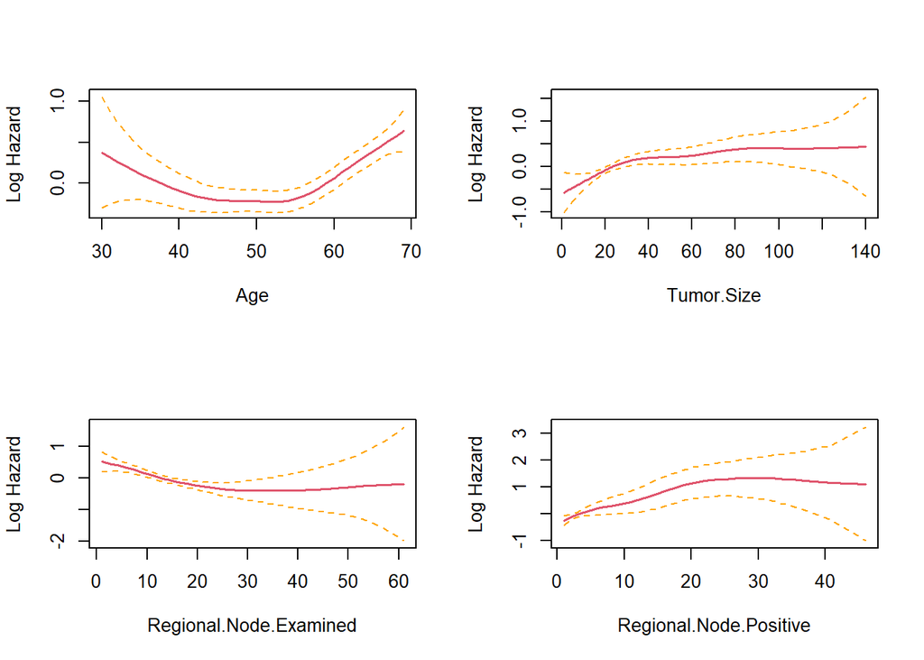

```r
par(mfrow = c(2,2))

termplot(cox_main, se=T, terms= 1, ylabs = "Log Hazard")
termplot(cox_main, se=T, terms= 5, ylabs = "Log Hazard")
termplot(cox_main, se=T, terms= 8, ylabs = "Log Hazard")
termplot(cox_main, se=T, terms= 9, ylabs = "Log Hazard")
```

Clearly, Tumor size, Regional node examined, and Regional node positive can be modelled as linear.I choose to model age as linear for simplicity sake.

#Step6: Interaction model

```r
cox_int <- coxph(
  surv_obj ~ (Age +
    Race + N.Stage + Grade + A.Stage +
    Tumor.Size + Estrogen.Status + Progesterone.Status +
    Regional.Node.Examined + Regional.Node.Positive)^2,
  data = seer_train
)
cox_int
```

```
## Call:
## coxph(formula = surv_obj ~ (Age + Race + N.Stage + Grade + A.Stage +
##     Tumor.Size + Estrogen.Status + Progesterone.Status + Regional.Node.Examined +
##     Regional.Node.Positive)^2, data = seer_train)
##
##                                                           coef  exp(coef)
## Age                                                  8.286e-02  1.086e+00
## RaceOther                                           -2.518e+00  8.061e-02
## RaceWhite                                           -5.562e+00  3.840e-03
## N.StageN2                                            5.589e+00  2.674e+02
## N.StageN3                                            1.575e+00  4.833e+00
## Grade1                                               7.657e+00  2.115e+03
## Grade2                                               6.687e+00  8.016e+02
## Grade3                                               7.666e+00  2.134e+03
## A.StageRegional                                     -5.077e+00  6.241e-03
## Tumor.Size                                           3.376e-02  1.034e+00
## Estrogen.StatusPositive                             -4.878e+00  7.614e-03
## Progesterone.StatusPositive                          3.936e+00  5.120e+01
## Regional.Node.Examined                               5.806e-02  1.060e+00
## Regional.Node.Positive                              -1.157e-01  8.907e-01
## Age:RaceOther                                       -1.138e-02  9.887e-01
## Age:RaceWhite                                        1.449e-02  1.015e+00
## Age:N.StageN2                                       -2.111e-02  9.791e-01
## Age:N.StageN3                                       -4.348e-02  9.575e-01
## Age:Grade1                                          -1.016e-01  9.034e-01
## Age:Grade2                                          -1.052e-01  9.002e-01
## Age:Grade3                                          -1.262e-01  8.814e-01
## Age:A.StageRegional                                  5.055e-02  1.052e+00
## Age:Tumor.Size                                       6.659e-06  1.000e+00
## Age:Estrogen.StatusPositive                          7.367e-03  1.007e+00
## Age:Progesterone.StatusPositive                      6.955e-03  1.007e+00
## Age:Regional.Node.Examined                          -1.209e-03  9.988e-01
## Age:Regional.Node.Positive                           3.125e-03  1.003e+00
## RaceOther:N.StageN2                                 -1.027e+00  3.580e-01
## RaceWhite:N.StageN2                                  2.465e-01  1.280e+00
## RaceOther:N.StageN3                                 -1.124e+00  3.249e-01
## RaceWhite:N.StageN3                                  8.400e-01  2.316e+00
## RaceOther:Grade1                                    -3.640e-01  6.949e-01
## RaceWhite:Grade1                                     3.452e+00  3.157e+01
## RaceOther:Grade2                                    -1.846e-01  8.315e-01
```

[output cut: 155 more lines]

```
## A.StageRegional:Regional.Node.Examined               5.476e-02  2.027  0.04267
## A.StageRegional:Regional.Node.Positive               5.467e-02  0.195  0.84503
## Tumor.Size:Estrogen.StatusPositive                   6.133e-03 -3.908 9.31e-05
## Tumor.Size:Progesterone.StatusPositive               5.228e-03  2.166  0.03029
## Tumor.Size:Regional.Node.Examined                    2.915e-04  0.294  0.76871
## Tumor.Size:Regional.Node.Positive                    5.142e-04  1.198  0.23078
## Estrogen.StatusPositive:Progesterone.StatusPositive  5.970e-01  0.882  0.37794
## Estrogen.StatusPositive:Regional.Node.Examined       2.505e-02  0.267  0.78915
## Estrogen.StatusPositive:Regional.Node.Positive       5.181e-02  0.253  0.80051
## Progesterone.StatusPositive:Regional.Node.Examined   1.925e-02 -0.433  0.66483
## Progesterone.StatusPositive:Regional.Node.Positive   4.116e-02  0.452  0.65159
## Regional.Node.Examined:Regional.Node.Positive        1.363e-03 -0.290  0.77170
##
## Likelihood ratio test=533.6  on 98 df, p=< 2.2e-16
## n= 3621, number of events= 556
```

```r
cox_step <- stepAIC(cox_int, direction = "both", trace = TRUE)
```

```
## Start:  AIC=8421.62
## surv_obj ~ (Age + Race + N.Stage + Grade + A.Stage + Tumor.Size +
##     Estrogen.Status + Progesterone.Status + Regional.Node.Examined +
##     Regional.Node.Positive)^2
```

[output not shown]

[output cut: 13 more lines]

```
##     Age:Regional.Node.Examined + Age:Regional.Node.Positive +
##     Race:N.Stage + Race:Grade + Race:A.Stage + Race:Tumor.Size +
##     Race:Estrogen.Status + Race:Progesterone.Status + Race:Regional.Node.Examined +
##     Race:Regional.Node.Positive + N.Stage:A.Stage + N.Stage:Tumor.Size +
##     N.Stage:Estrogen.Status + N.Stage:Progesterone.Status + N.Stage:Regional.Node.Examined +
##     N.Stage:Regional.Node.Positive + Grade:A.Stage + Grade:Tumor.Size +
##     Grade:Estrogen.Status + Grade:Progesterone.Status + Grade:Regional.Node.Examined +
##     Grade:Regional.Node.Positive + A.Stage:Tumor.Size + A.Stage:Estrogen.Status +
##     A.Stage:Progesterone.Status + A.Stage:Regional.Node.Examined +
##     A.Stage:Regional.Node.Positive + Tumor.Size:Estrogen.Status +
##     Tumor.Size:Progesterone.Status + Tumor.Size:Regional.Node.Examined +
##     Tumor.Size:Regional.Node.Positive + Estrogen.Status:Progesterone.Status +
##     Estrogen.Status:Regional.Node.Examined + Estrogen.Status:Regional.Node.Positive +
##     Progesterone.Status:Regional.Node.Examined + Progesterone.Status:Regional.Node.Positive +
##     Regional.Node.Examined:Regional.Node.Positive
```

[output not shown]

[output cut: 1253 more lines]

```
## - Tumor.Size:Estrogen.Status                     1 8374.5
##
## Step:  AIC=8359.22
## surv_obj ~ Age + Race + N.Stage + Grade + A.Stage + Tumor.Size +
##     Estrogen.Status + Progesterone.Status + Regional.Node.Examined +
##     Regional.Node.Positive + Age:N.Stage + Age:Grade + Age:A.Stage +
##     Age:Regional.Node.Examined + Age:Regional.Node.Positive +
##     Race:Tumor.Size + Race:Estrogen.Status + Race:Progesterone.Status +
##     N.Stage:A.Stage + N.Stage:Tumor.Size + N.Stage:Estrogen.Status +
##     N.Stage:Progesterone.Status + Grade:A.Stage + Grade:Tumor.Size +
##     Grade:Regional.Node.Examined + Grade:Regional.Node.Positive +
##     A.Stage:Estrogen.Status + A.Stage:Progesterone.Status + A.Stage:Regional.Node.Examined +
##     Tumor.Size:Estrogen.Status + Tumor.Size:Progesterone.Status +
##     Tumor.Size:Regional.Node.Positive + Progesterone.Status:Regional.Node.Positive +
##     Regional.Node.Examined:Regional.Node.Positive
```

[output not shown]

[output cut: 67 more lines]

```
## + N.Stage:Grade                                  6 8367.4
## - Tumor.Size:Estrogen.Status                     1 8371.6
##
## Step:  AIC=8356.35
## surv_obj ~ Age + Race + N.Stage + Grade + A.Stage + Tumor.Size +
##     Estrogen.Status + Progesterone.Status + Regional.Node.Examined +
##     Regional.Node.Positive + Age:N.Stage + Age:Grade + Age:A.Stage +
##     Age:Regional.Node.Examined + Age:Regional.Node.Positive +
##     Race:Tumor.Size + Race:Estrogen.Status + Race:Progesterone.Status +
##     N.Stage:A.Stage + N.Stage:Tumor.Size + N.Stage:Estrogen.Status +
##     N.Stage:Progesterone.Status + Grade:A.Stage + Grade:Tumor.Size +
##     Grade:Regional.Node.Examined + Grade:Regional.Node.Positive +
##     A.Stage:Estrogen.Status + A.Stage:Regional.Node.Examined +
##     Tumor.Size:Estrogen.Status + Tumor.Size:Progesterone.Status +
##     Tumor.Size:Regional.Node.Positive + Regional.Node.Examined:Regional.Node.Positive
```

[output not shown]

[output not shown]

[output cut: 635 more lines]

```
## + N.Stage:A.Stage                                2 8344.3
## + N.Stage:Regional.Node.Positive                 2 8344.7
## + Age:N.Stage                                    2 8344.8
## - Age:A.Stage                                    1 8344.9
## + Race:Regional.Node.Positive                    2 8345.1
## + Race:Regional.Node.Examined                    2 8345.2
## + Grade:Tumor.Size                               3 8345.2
## + Grade:Estrogen.Status                          3 8346.2
## - Race:Progesterone.Status                       2 8346.4
## + Race:N.Stage                                   4 8346.4
## + Grade:Progesterone.Status                      3 8346.6
## - A.Stage:Regional.Node.Examined                 1 8348.7
## + Race:Grade                                     5 8348.9
## + N.Stage:Grade                                  6 8350.5
## - Tumor.Size:Estrogen.Status                     1 8354.6
```

```r
summary(cox_step)
```

```
## Call:
## coxph(formula = surv_obj ~ Age + Race + N.Stage + Grade + A.Stage +
##     Tumor.Size + Estrogen.Status + Progesterone.Status + Regional.Node.Examined +
##     Regional.Node.Positive + Age:Grade + Age:A.Stage + Race:Estrogen.Status +
##     Race:Progesterone.Status + N.Stage:Tumor.Size + Grade:Regional.Node.Positive +
##     A.Stage:Regional.Node.Examined + Tumor.Size:Estrogen.Status +
##     Tumor.Size:Progesterone.Status + Tumor.Size:Regional.Node.Positive,
##     data = seer_train)
##
##   n= 3621, number of events= 556
##
##                                              coef  exp(coef)   se(coef)      z
## Age                                     0.0029602  1.0029646  0.0423802  0.070
## RaceOther                              -0.7165137  0.4884522  0.6139682 -1.167
## RaceWhite                               0.3482741  1.4166204  0.3472041  1.003
## N.StageN2                               0.7459290  2.1083993  0.2085589  3.577
## N.StageN3                               1.0946701  2.9881968  0.3588274  3.051
## Grade1                                 -1.6370365  0.1945558  2.2122000 -0.740
## Grade2                                 -0.3584755  0.6987408  1.8876962 -0.190
## Grade3                                  1.2432821  3.4669739  1.8808790  0.661
## A.StageRegional                        -4.5318419  0.0107608  1.2245670 -3.701
## Tumor.Size                              0.0176257  1.0177819  0.0047660  3.698
## Estrogen.StatusPositive                 0.8198313  2.2701167  0.4785353  1.713
## Progesterone.StatusPositive            -0.7171185  0.4881568  0.3712883 -1.931
## Regional.Node.Examined                 -0.1141537  0.8921208  0.0281163 -4.060
## Regional.Node.Positive                  0.0158577  1.0159841  0.0768856  0.206
## Age:Grade1                             -0.0085252  0.9915111  0.0423798 -0.201
## Age:Grade2                             -0.0156073  0.9845138  0.0377052 -0.414
## Age:Grade3                             -0.0388397  0.9619049  0.0376860 -1.031
## Age:A.StageRegional                     0.0495136  1.0507599  0.0207561  2.386
## RaceOther:Estrogen.StatusPositive      -1.9419618  0.1434223  0.7891154 -2.461
## RaceWhite:Estrogen.StatusPositive      -0.7886637  0.4544517  0.4390203 -1.796
## RaceOther:Progesterone.StatusPositive   1.9052863  6.7213314  0.8035540  2.371
## RaceWhite:Progesterone.StatusPositive  -0.1373237  0.8716880  0.3442611 -0.399
## N.StageN2:Tumor.Size                   -0.0084042  0.9916310  0.0048171 -1.745
## N.StageN3:Tumor.Size                   -0.0150095  0.9851026  0.0074022 -2.028
## Grade1:Regional.Node.Positive           0.0789912  1.0821948  0.0769275  1.027
## Grade2:Regional.Node.Positive           0.0088802  1.0089198  0.0743604  0.119
## Grade3:Regional.Node.Positive           0.0189926  1.0191741  0.0742918  0.256
## A.StageRegional:Regional.Node.Examined  0.0858968  1.0896938  0.0278295  3.087
```

[output cut: 60 more lines]

```
## RaceWhite:Progesterone.StatusPositive    0.87169     1.1472 0.4439412    1.7116
## N.StageN2:Tumor.Size                     0.99163     1.0084 0.9823127    1.0010
## N.StageN3:Tumor.Size                     0.98510     1.0151 0.9709138    0.9995
## Grade1:Regional.Node.Positive            1.08219     0.9240 0.9307320    1.2583
## Grade2:Regional.Node.Positive            1.00892     0.9912 0.8720893    1.1672
## Grade3:Regional.Node.Positive            1.01917     0.9812 0.8810713    1.1789
## A.StageRegional:Regional.Node.Examined   1.08969     0.9177 1.0318485    1.1508
## Tumor.Size:Estrogen.StatusPositive       0.98073     1.0196 0.9713733    0.9902
## Tumor.Size:Progesterone.StatusPositive   1.00934     0.9907 1.0007014    1.0181
## Tumor.Size:Regional.Node.Positive        1.00076     0.9992 0.9999544    1.0016
##
## Concordance= 0.746  (se = 0.011 )
## Likelihood ratio test= 480  on 31 df,   p=<2e-16
## Wald test            = 563.1  on 31 df,   p=<2e-16
## Score (logrank) test = 787.1  on 31 df,   p=<2e-16
```

```r
cox_step <- coxph(
  surv_obj ~
    Age +
    Race +
    N.Stage +
    Grade +
    Tumor.Size +
    Estrogen.Status +
    Progesterone.Status +
    Regional.Node.Examined +
    Regional.Node.Positive +

    # Interaction terms selected by stepAIC
    Age:Grade +
    Race:Estrogen.Status +
    Race:Progesterone.Status +
    N.Stage:Tumor.Size +
    Grade:Regional.Node.Positive +
    Grade:Regional.Node.Examined +
    Tumor.Size:Estrogen.Status +
    Tumor.Size:Progesterone.Status +
    Estrogen.Status:Regional.Node.Examined +
    Regional.Node.Examined:Regional.Node.Positive,

  data = seer_train
)
cox_step
```

```
## Call:
## coxph(formula = surv_obj ~ Age + Race + N.Stage + Grade + Tumor.Size +
##     Estrogen.Status + Progesterone.Status + Regional.Node.Examined +
##     Regional.Node.Positive + Age:Grade + Race:Estrogen.Status +
##     Race:Progesterone.Status + N.Stage:Tumor.Size + Grade:Regional.Node.Positive +
##     Grade:Regional.Node.Examined + Tumor.Size:Estrogen.Status +
##     Tumor.Size:Progesterone.Status + Estrogen.Status:Regional.Node.Examined +
##     Regional.Node.Examined:Regional.Node.Positive, data = seer_train)
##
##                                                      coef  exp(coef)   se(coef)
## Age                                             0.0321993  1.0327233  0.0400290
## RaceOther                                      -0.6234175  0.5361092  0.6192005
## RaceWhite                                       0.4167318  1.5169955  0.3564507
## N.StageN2                                       0.5911487  1.8060618  0.2067943
## N.StageN3                                       0.6708472  1.9558936  0.3050549
## Grade1                                         -1.2419156  0.2888304  2.2657967
## Grade2                                         -0.1012635  0.9036949  1.9190810
## Grade3                                          1.6119101  5.0123761  1.9102395
## Tumor.Size                                      0.0200462  1.0202485  0.0047267
## Estrogen.StatusPositive                         0.7274995  2.0698984  0.5190920
## Progesterone.StatusPositive                    -0.7080510  0.4926033  0.3647939
## Regional.Node.Examined                          0.0666950  1.0689694  0.0463146
## Regional.Node.Positive                         -0.0068204  0.9932028  0.0801025
## Age:Grade1                                      0.0068056  1.0068288  0.0451152
## Age:Grade2                                      0.0025348  1.0025380  0.0406378
## Age:Grade3                                     -0.0212710  0.9789537  0.0406137
## RaceOther:Estrogen.StatusPositive              -2.0563437  0.1279208  0.7765876
## RaceWhite:Estrogen.StatusPositive              -0.9208994  0.3981608  0.4320997
## RaceOther:Progesterone.StatusPositive           1.9193746  6.8166937  0.7901935
## RaceWhite:Progesterone.StatusPositive          -0.0911720  0.9128607  0.3344046
## N.StageN2:Tumor.Size                           -0.0044653  0.9955446  0.0043940
## N.StageN3:Tumor.Size                           -0.0043878  0.9956218  0.0043958
## Grade1:Regional.Node.Positive                   0.1301582  1.1390085  0.0799444
## Grade2:Regional.Node.Positive                   0.0691585  1.0716061  0.0750549
## Grade3:Regional.Node.Positive                   0.0844385  1.0881060  0.0751609
## Grade1:Regional.Node.Examined                  -0.0979673  0.9066785  0.0564284
## Grade2:Regional.Node.Examined                  -0.1040596  0.9011716  0.0484186
## Grade3:Regional.Node.Examined                  -0.1117774  0.8942433  0.0481672
## Tumor.Size:Estrogen.StatusPositive             -0.0192402  0.9809437  0.0047024
## Tumor.Size:Progesterone.StatusPositive          0.0081347  1.0081678  0.0041955
```

[output cut: 23 more lines]

```
## N.StageN2:Tumor.Size                           -1.016  0.30951
## N.StageN3:Tumor.Size                           -0.998  0.31819
## Grade1:Regional.Node.Positive                   1.628  0.10350
## Grade2:Regional.Node.Positive                   0.921  0.35682
## Grade3:Regional.Node.Positive                   1.123  0.26125
## Grade1:Regional.Node.Examined                  -1.736  0.08254
## Grade2:Regional.Node.Examined                  -2.149  0.03162
## Grade3:Regional.Node.Examined                  -2.321  0.02031
## Tumor.Size:Estrogen.StatusPositive             -4.092 4.28e-05
## Tumor.Size:Progesterone.StatusPositive          1.939  0.05251
## Estrogen.StatusPositive:Regional.Node.Examined  0.834  0.40418
## Regional.Node.Examined:Regional.Node.Positive  -0.465  0.64227
##
## Likelihood ratio test=464.7  on 32 df, p=< 2.2e-16
## n= 3621, number of events= 556
```

```r
library(lmtest)
lrtest(cox_main, cox_step)
```

```
## Likelihood ratio test
##
## Model 1: surv_obj ~ pspline(Age) + Race + N.Stage + Grade + pspline(Tumor.Size) +
##     Estrogen.Status + Progesterone.Status + pspline(Regional.Node.Examined) +
##     pspline(Regional.Node.Positive)
## Model 2: surv_obj ~ Age + Race + N.Stage + Grade + Tumor.Size + Estrogen.Status +
##     Progesterone.Status + Regional.Node.Examined + Regional.Node.Positive +
##     Age:Grade + Race:Estrogen.Status + Race:Progesterone.Status +
##     N.Stage:Tumor.Size + Grade:Regional.Node.Positive + Grade:Regional.Node.Examined +
##     Tumor.Size:Estrogen.Status + Tumor.Size:Progesterone.Status +
##     Estrogen.Status:Regional.Node.Examined + Regional.Node.Examined:Regional.Node.Positive
##      #Df  LogLik     Df  Chisq Pr(>Chisq)
## 1 24.861 -4151.1
## 2 32.000 -4147.3 7.1387 7.6701     0.3626
```

Therefore, the more complex interaction model does not provide a statistically meaningful improvement over the simpler spline-adjusted model.

For parsimony and interpretability, the spline main-effects model is preferred

# Final model

```r
cox_final <- coxph(
  surv_obj ~ (Age +
    Race + N.Stage + Grade + A.Stage +
    Tumor.Size + Estrogen.Status + Progesterone.Status +
    Regional.Node.Examined + Regional.Node.Positive),
  data = seer_train
)

cox_final
```

```
## Call:
## coxph(formula = surv_obj ~ (Age + Race + N.Stage + Grade + A.Stage +
##     Tumor.Size + Estrogen.Status + Progesterone.Status + Regional.Node.Examined +
##     Regional.Node.Positive), data = seer_train)
##
##                                  coef exp(coef)  se(coef)      z        p
## Age                          0.022389  1.022641  0.004939  4.533 5.81e-06
## RaceOther                   -0.809701  0.444991  0.224189 -3.612 0.000304
## RaceWhite                   -0.374240  0.687812  0.133848 -2.796 0.005174
## N.StageN2                    0.482610  1.620297  0.114947  4.199 2.69e-05
## N.StageN3                    0.603057  1.827697  0.189062  3.190 0.001424
## Grade1                      -1.568264  0.208407  0.396717 -3.953 7.71e-05
## Grade2                      -1.124557  0.324796  0.362935 -3.099 0.001945
## Grade3                      -0.727955  0.482895  0.361739 -2.012 0.044180
## A.StageRegional             -0.372232  0.689195  0.193253 -1.926 0.054088
## Tumor.Size                   0.007269  1.007295  0.001732  4.197 2.70e-05
## Estrogen.StatusPositive     -0.655831  0.519011  0.143296 -4.577 4.72e-06
## Progesterone.StatusPositive -0.423939  0.654464  0.112778 -3.759 0.000171
## Regional.Node.Examined      -0.028939  0.971476  0.006785 -4.265 2.00e-05
## Regional.Node.Positive       0.056387  1.058007  0.011879  4.747 2.07e-06
##
## Likelihood ratio test=417.5  on 14 df, p=< 2.2e-16
## n= 3621, number of events= 556
```

# Step 7: Checking assumptions and Model Diagnosis

```r
test_ph_rank = cox.zph(cox_final, transform = "rank")
test_ph_rank
```

```
##                          chisq df       p
## Age                     0.0108  1 0.91706
## Race                    1.3771  2 0.50230
## N.Stage                 2.6479  2 0.26608
## Grade                   1.7679  3 0.62194
## A.Stage                 3.6632  1 0.05563
## Tumor.Size              0.3789  1 0.53818
## Estrogen.Status        20.6371  1 5.6e-06
## Progesterone.Status    27.0933  1 1.9e-07
## Regional.Node.Examined  1.1294  1 0.28790
## Regional.Node.Positive  0.5862  1 0.44389
## GLOBAL                 37.9204 14 0.00053
```

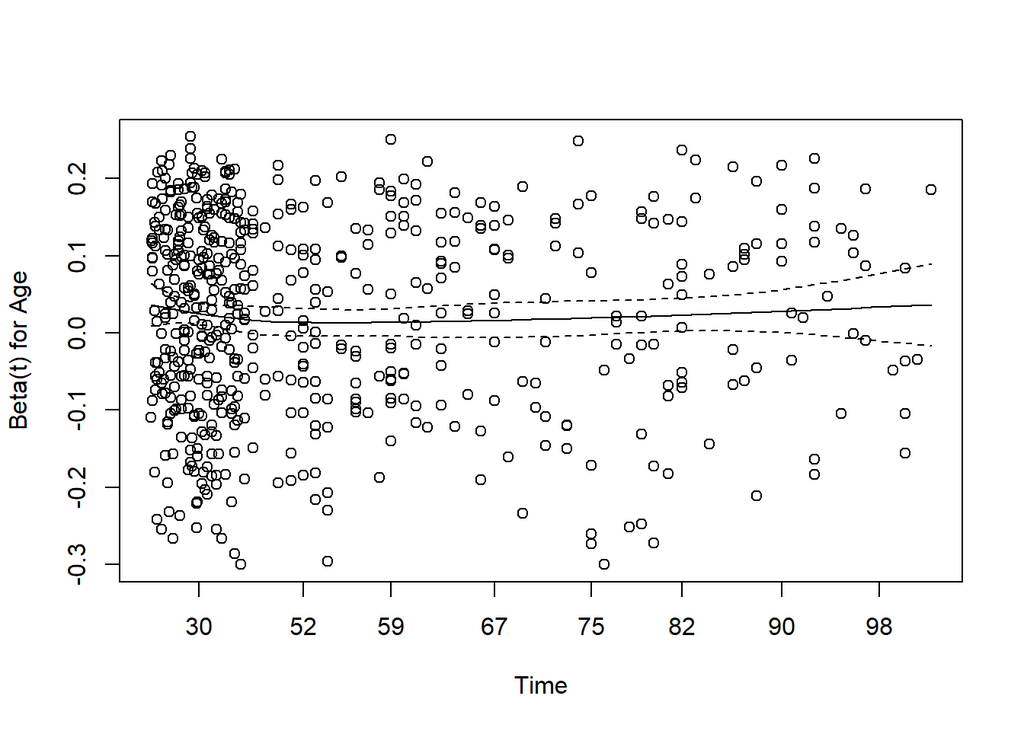

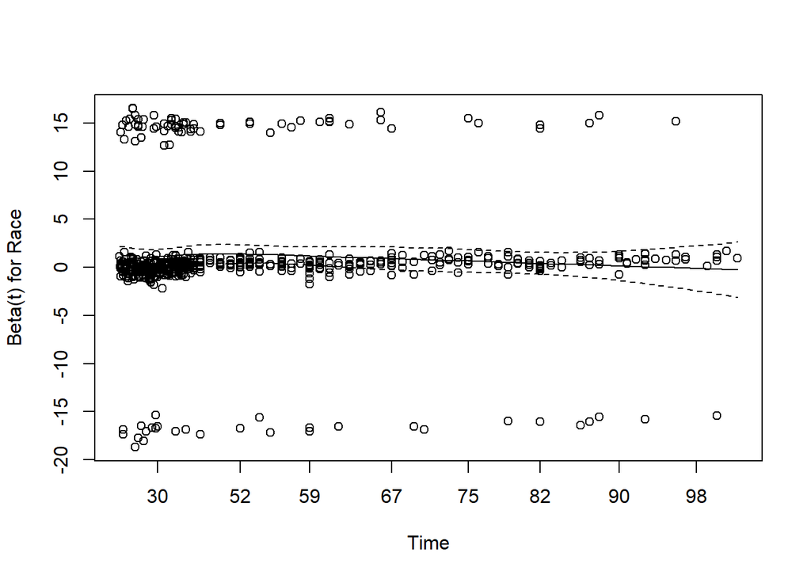

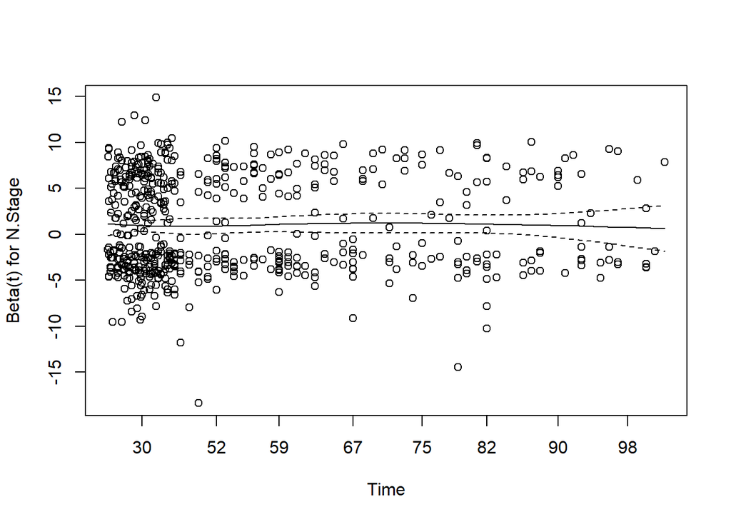

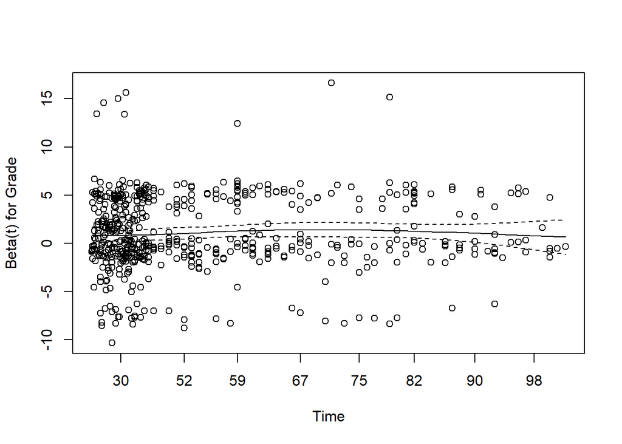

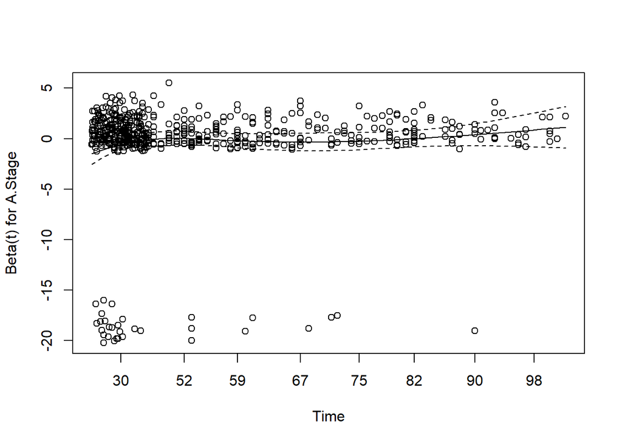

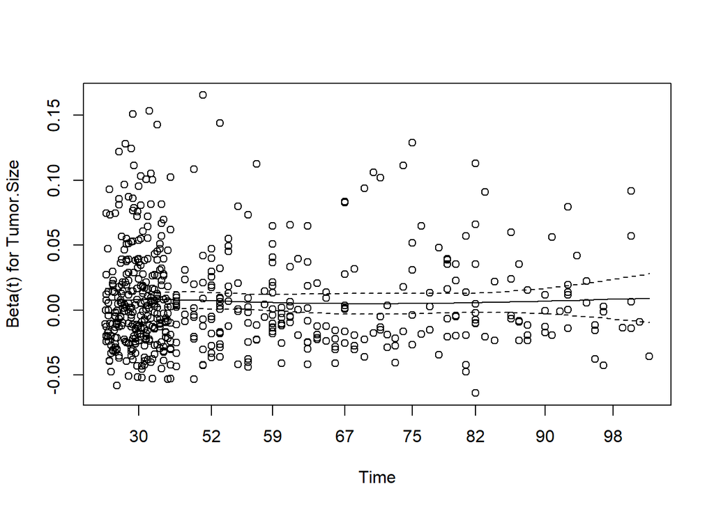

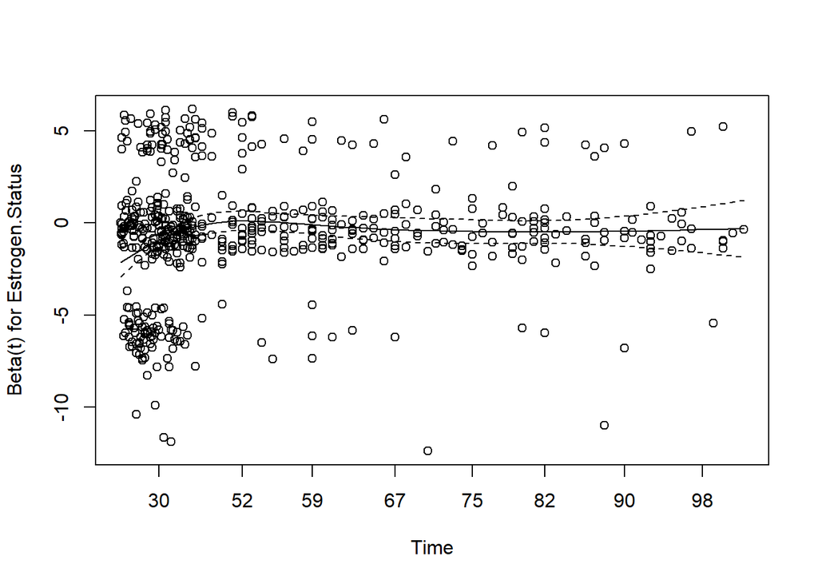

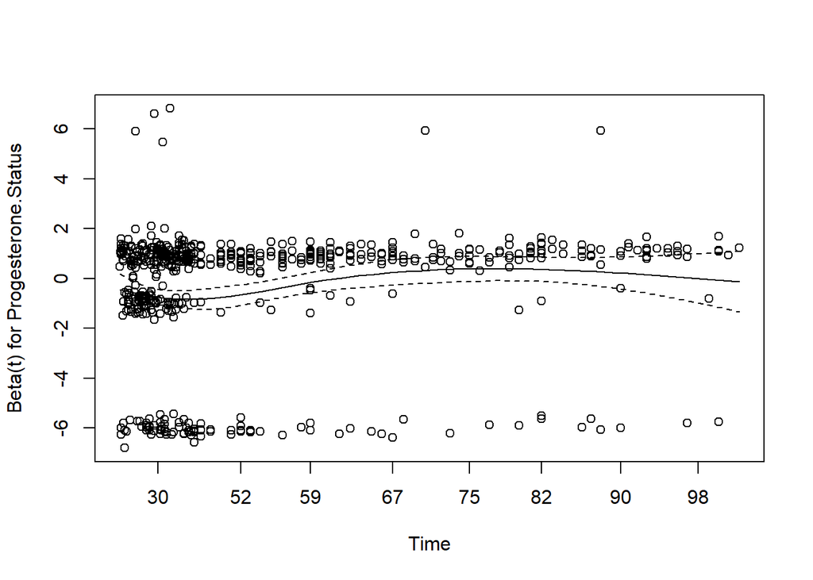

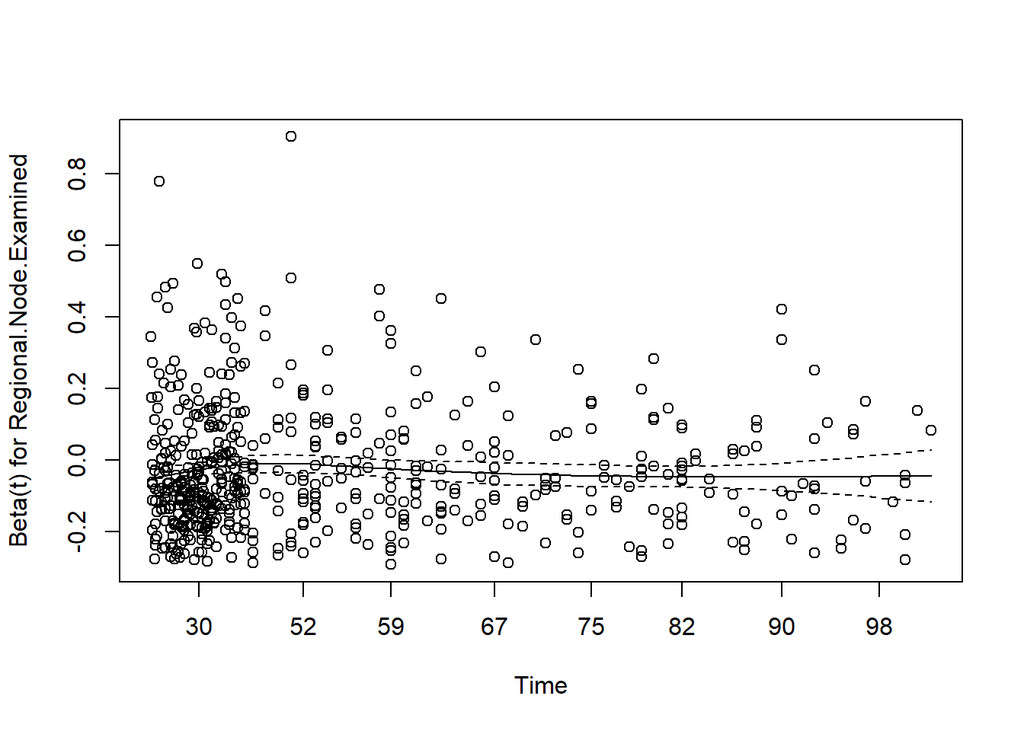

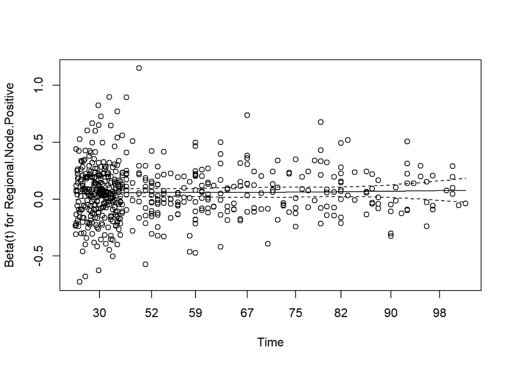

```r
plot(test_ph_rank)
```

```r
cox_strat <- coxph(
  surv_obj ~ Age + Race + N.Stage + Grade + Tumor.Size +
    Regional.Node.Examined + Regional.Node.Positive +
    strata(Estrogen.Status) +
    strata(Progesterone.Status),
  data = seer_train
)

summary(cox_strat)
```

```
## Call:
## coxph(formula = surv_obj ~ Age + Race + N.Stage + Grade + Tumor.Size +
##     Regional.Node.Examined + Regional.Node.Positive + strata(Estrogen.Status) +
##     strata(Progesterone.Status), data = seer_train)
##
##   n= 3621, number of events= 556
##
##                             coef exp(coef)  se(coef)      z Pr(>|z|)
## Age                     0.022008  1.022252  0.004932  4.462 8.11e-06 ***
## RaceOther              -0.791340  0.453237  0.224354 -3.527 0.000420 ***
## RaceWhite              -0.367631  0.692372  0.133837 -2.747 0.006017 **
## N.StageN2               0.494103  1.639028  0.114664  4.309 1.64e-05 ***
## N.StageN3               0.670433  1.955083  0.186812  3.589 0.000332 ***
## Grade1                 -1.505480  0.221911  0.397933 -3.783 0.000155 ***
## Grade2                 -1.061494  0.345939  0.364278 -2.914 0.003569 **
## Grade3                 -0.668869  0.512288  0.362957 -1.843 0.065354 .
## Tumor.Size              0.007092  1.007117  0.001741  4.073 4.64e-05 ***
## Regional.Node.Examined -0.029166  0.971256  0.006786 -4.298 1.72e-05 ***
## Regional.Node.Positive  0.054190  1.055686  0.011814  4.587 4.49e-06 ***
## ---
## Signif. codes:  0 '***' 0.001 '**' 0.01 '*' 0.05 '.' 0.1 ' ' 1
##
##                        exp(coef) exp(-coef) lower .95 upper .95
## Age                       1.0223     0.9782    1.0124    1.0322
## RaceOther                 0.4532     2.2063    0.2920    0.7036
## RaceWhite                 0.6924     1.4443    0.5326    0.9000
## N.StageN2                 1.6390     0.6101    1.3091    2.0521
## N.StageN3                 1.9551     0.5115    1.3557    2.8195
## Grade1                    0.2219     4.5063    0.1017    0.4841
## Grade2                    0.3459     2.8907    0.1694    0.7064
## Grade3                    0.5123     1.9520    0.2515    1.0434
## Tumor.Size                1.0071     0.9929    1.0037    1.0106
## Regional.Node.Examined    0.9713     1.0296    0.9584    0.9843
## Regional.Node.Positive    1.0557     0.9473    1.0315    1.0804
##
## Concordance= 0.698  (se = 0.014 )
## Likelihood ratio test= 282  on 11 df,   p=<2e-16
## Wald test            = 297.8  on 11 df,   p=<2e-16
## Score (logrank) test = 330.2  on 11 df,   p=<2e-16
```

```r
test_ph_rank = cox.zph(cox_strat, transform = "rank")
test_ph_rank
```

```
##                           chisq df    p
## Age                    3.90e-02  1 0.84
## Race                   1.23e+00  2 0.54
## N.Stage                1.04e+00  2 0.59
## Grade                  6.97e-01  3 0.87
## Tumor.Size             1.40e-01  1 0.71
## Regional.Node.Examined 3.81e-01  1 0.54
## Regional.Node.Positive 3.21e-05  1 1.00
## GLOBAL                 4.90e+00 11 0.94
```

After stratifying on Estrogen.Status and Progesterone.Status, the Cox model fully satisfies the proportional hazards assumption, as indicated by non-significant PH tests for all covariates and a strong global p-value (0.94).

```r
dfb <- residuals(cox_strat, type = "dfbeta")
index.obs <- 1:nrow(dfb)

coef_names <- colnames(dfb)
coef_names
```

[output not shown]

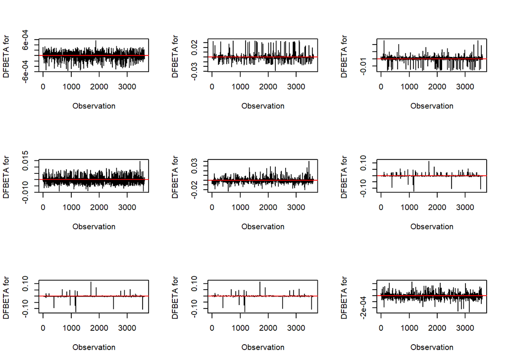

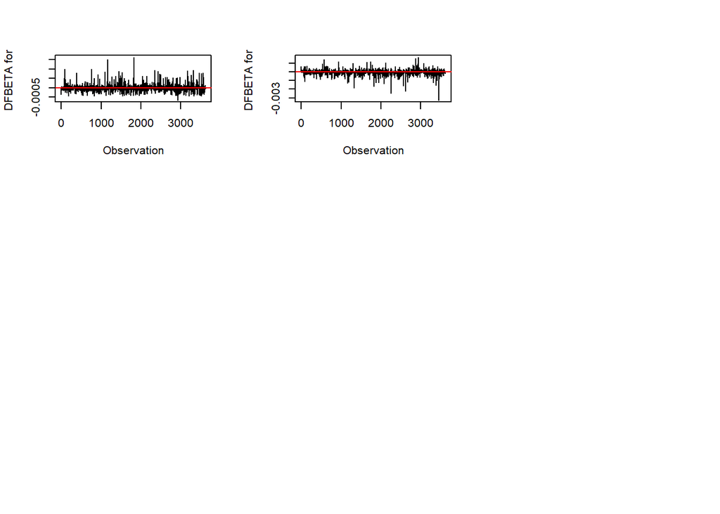

```r
par(mfrow = c(3, 3))   # adjust grid as needed

for (j in 1:ncol(dfb)) {
  plot(index.obs, dfb[, j], type = "h",
       xlab = "Observation",
       ylab = paste("DFBETA for", coef_names[j]),
       main = coef_names[j])
  abline(h = 0, col = "red")
}
```

# Risk groups and KM curves for Results

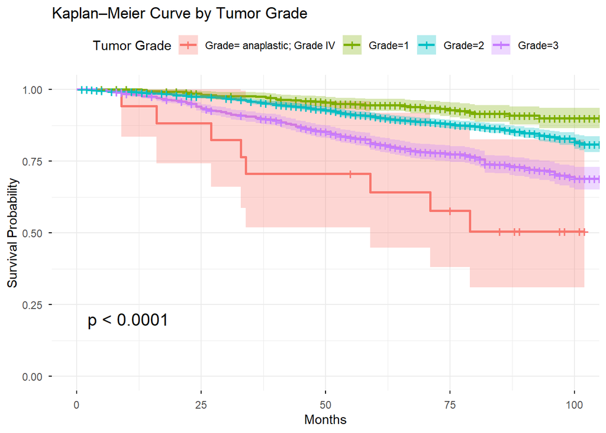

```r
fit_grade <- survfit(
  Surv(Survival.Months, status_event) ~ Grade,
  data = seer_train
)

ggsurvplot(
  fit_grade,
  data = seer_train,
  risk.table = FALSE,      # <-- removed risk table
  pval = TRUE,
  conf.int = TRUE,
  legend.title = "Tumor Grade",
  xlab = "Months",
  ylab = "Survival Probability",
  ggtheme = theme_minimal(),
  title = "Kaplan–Meier Curve by Tumor Grade"
)
```

Higher tumor grade corresponds to worse survival. Grade I shows the best survival, whereas Grade III–IV decline sharply, indicating much more aggressive tumor biology. Survival curves differ significantly (p < 0.001).

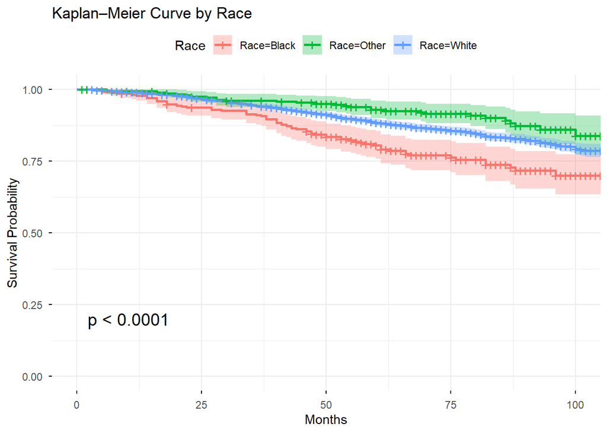

```r
fit_race <- survfit(
  Surv(Survival.Months, status_event) ~ Race,
  data = seer_train
)

ggsurvplot(
  fit_race,
  data = seer_train,
  risk.table = FALSE,      # <-- removed risk table
  pval = TRUE,
  conf.int = TRUE,
  legend.title = "Race",
  xlab = "Months",
  ylab = "Survival Probability",
  ggtheme = theme_minimal(),
  title = "Kaplan–Meier Curve by Race"
)
```

Racial groups have visibly different survival probabilities. The group with the highest curve maintains better long-term survival, while others decline earlier, suggesting disparities possibly related to access to care, tumor biology, or socioeconomic factors. The p-value indicates statistically significant differences.

#Part II: Comparison with prediction made with DeepSurv

```r
library(dnn)
library(survival)
library(survcomp)
library(dplyr)

set.seed(2025)

## --------------------------------------------------
## 1. Cox formula
## --------------------------------------------------
cox_formula <- Surv(Survival.Months, status_event) ~
  Age + Race + Marital.Status + N.Stage + Grade + A.Stage +
  Tumor.Size + Estrogen.Status + Progesterone.Status +
  Regional.Node.Examined + Regional.Node.Positive

## --------------------------------------------------
## 2. Build design matrix (for DeepSurv input dimension)
## --------------------------------------------------
X_train <- model.matrix(cox_formula, data = seer_train)[, -1]  # drop intercept
p <- ncol(X_train)

## --------------------------------------------------
## 3. Define DeepSurv network
## --------------------------------------------------
ds_model <- dNNmodel(
  units       = c(64, 32, 1),           # two hidden layers + 1 output
  activation  = c("relu", "relu", "idu"),
  input_shape = p
)

## --------------------------------------------------
## 4. Fit DeepSurv model on scaled TRAINING data
## --------------------------------------------------
seer_train_scaled <- seer_train %>%
  mutate(
    Tumor.Size             = scale(Tumor.Size),
    Age                    = scale(Age),
    Regional.Node.Examined = scale(Regional.Node.Examined),
    Regional.Node.Positive = scale(Regional.Node.Positive)
  )

fit_deepsurv <- deepSurv(
  formula    = cox_formula,
  model      = ds_model,
  data       = seer_train_scaled,
  epochs     = 3000,
  batch_size = 32,
  lr_rate    = 1e-3,
  alpha      = 0.7,
  lambda     = 1,
  verbose    = 1
)
```

```
##  Final cost:  4267.401
```

```r
## --------------------------------------------------
## 5. C-index for stratified Cox model (validation)
##     assumes cox_strat already fitted
## --------------------------------------------------
lp_cox_valid <- predict(cox_strat, newdata = seer_valid, type = "risk")

c_index_cox <- concordance.index(
  x          = lp_cox_valid,
  surv.time  = seer_valid$Survival.Months,
  surv.event = seer_valid$status_event
)

c_index_cox$c.index
```

```
## [1] 0.6909307
```

```r
## --------------------------------------------------
## 6. C-index for DeepSurv (validation)
## --------------------------------------------------
X_valid <- model.matrix(cox_formula, data = seer_valid)[, -1]

pred_ds <- predict(fit_deepsurv, X_valid, type = "risk")
# ensure numeric risk scores
risk_ds <- as.numeric(pred_ds$risk)

c_index_ds <- concordance.index(
  x          = risk_ds,
  surv.time  = seer_valid$Survival.Months,
  surv.event = seer_valid$status_event)

c_index_ds$c.index
```

```
## [1] 0.6575612
```